# Quiz 2

cwl

6/1/2021

### 2.

Load the cement data using the commands:

```r
library(AppliedPredictiveModeling)
data(concrete)
library(caret)
set.seed(1000)
inTrain = createDataPartition(mixtures$CompressiveStrength, p = 3/4)[[1]]
training = mixtures[ inTrain,]
testing = mixtures[-inTrain,]
```

Make a plot of the outcome (CompressiveStrength) versus the index of the samples. Color by each of the variables in the data set (you may find the cut2() function in the Hmisc package useful for turning continuous covariates into factors). What do you notice in these plots?

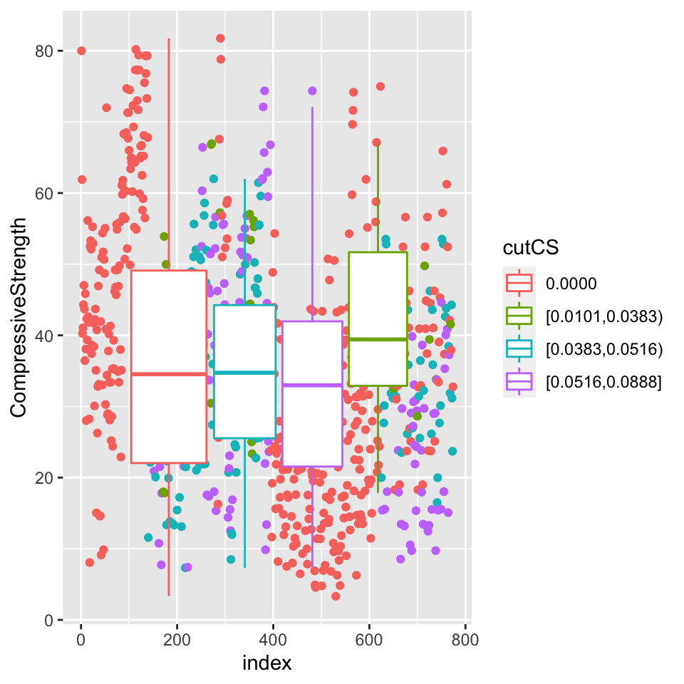

```r
library(Hmisc)
cutCS <- cut2(training$FlyAsh, g = 5) # divided into 5 groups
index <- seq_along(1:nrow(training))
# CompressiveStrength (check the variable any relation to
ggplot(data=training,
       aes(x=index,
           y=CompressiveStrength,
           color=cutCS)) + geom_point()  + geom_boxplot()
```

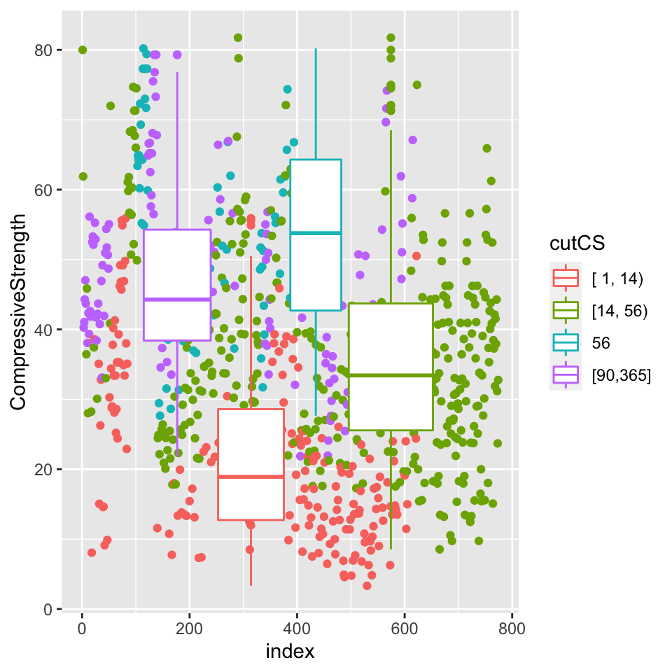

```r
cutCS <- cut2(training$Age, g = 5) # divided into 5 groups
index <- seq_along(1:nrow(training))
# CompressiveStrength (check the variable any relation to
ggplot(data=training,
       aes(x=index,
           y=CompressiveStrength,
           color=cutCS)) + geom_point()  + geom_boxplot()
```

Answer: There is a non-random pattern in the plot of the outcome versus index that does not appear to be perfectly explained by any predictor suggesting a variable may be missing.

### 3.

Load the cement data using the commands:

```r
library(AppliedPredictiveModeling)
data(concrete)
library(caret)
set.seed(1000)
inTrain = createDataPartition(mixtures$CompressiveStrength, p = 3/4)[[1]]
training = mixtures[ inTrain,]
testing = mixtures[-inTrain,]
```

Make a histogram and confirm the SuperPlasticizer variable is skewed. Normally you might use the log transform to try to make the data more symmetric. Why would that be a poor choice for this variable?

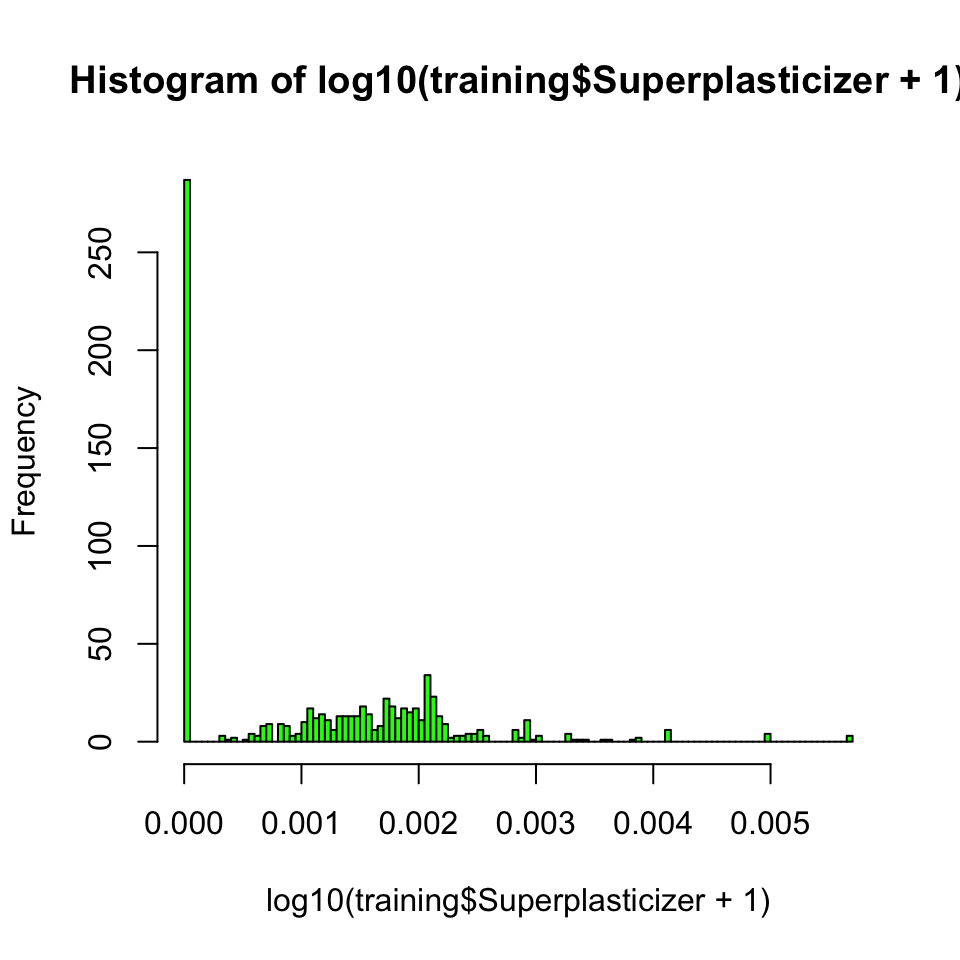

```r
hist(log10(training$Superplasticizer + 1), col="green", breaks = 100)
```

Answer: There are a large number of values that are the same and even if you took the log(SuperPlasticizer + 1) they would still all be identical so the distribution would not be symmetric.

### 4.

Load the Alzheimer’s disease data using the commands:

```r
library(caret)
library(AppliedPredictiveModeling)
set.seed(3433)
data(AlzheimerDisease)
adData = data.frame(diagnosis,predictors)
inTrain = createDataPartition(adData$diagnosis, p = 3/4)[[1]]
training = adData[ inTrain,]
testing = adData[-inTrain,]
```

Find all the predictor variables in the training set that begin with IL. Perform principal components on these variables with the preProcess() function from the caret package. Calculate the number of principal components needed to capture 90% of the variance. How many are there?

```r
trainingIL <- training[,grep("^IL", names(training))]
testingIL <- testing[,grep("^IL", names(testing))]

preProc <- preProcess(trainingIL,method="pca",thresh=0.9)
preProc
```

```
## Created from 251 samples and 12 variables
##
## Pre-processing:
##   - centered (12)
##   - ignored (0)
##   - principal component signal extraction (12)
##   - scaled (12)
##
## PCA needed 9 components to capture 90 percent of the variance
```

Answer:9

### 5.

Load the Alzheimer’s disease data using the commands:

```r
library(caret)
library(AppliedPredictiveModeling)
set.seed(3433)
data(AlzheimerDisease)
adData = data.frame(diagnosis,predictors)
inTrain = createDataPartition(adData$diagnosis, p = 3/4)[[1]]
training = adData[ inTrain,]
testing = adData[-inTrain,]
```

Create a training data set consisting of only the predictors with variable names beginning with IL and the diagnosis. Build two predictive models, one using the predictors as they are and one using PCA with principal components explaining 80% of the variance in the predictors. Use method=“glm” in the train function.

```r
# Filter dataset
trainingIL <- training[,grep("^IL|^diagnosis", names(training))]
testingIL <- testing[,grep("^IL|^diagnosis", names(testing))]

# 1. Without PCA preprocessing
modelFit <- train(diagnosis ~.,data=trainingIL, method="glm")
modelFit # training model accuracy
```

```
## Generalized Linear Model
##
## 251 samples
##  12 predictor
##   2 classes: 'Impaired', 'Control'
##
## No pre-processing
## Resampling: Bootstrapped (25 reps)
## Summary of sample sizes: 251, 251, 251, 251, 251, 251, ...
## Resampling results:
##
##   Accuracy  Kappa
##   0.689539  0.03220119
```

```r
modelFit$finalModel #view training model coefficients
```

```
##
## Call:  NULL
##
## Coefficients:
##   (Intercept)          IL_11          IL_13          IL_16         IL_17E
##       5.12574       -0.16303        3.71819       -0.16950        0.30158
##     IL_1alpha           IL_3           IL_4           IL_5           IL_6
##      -0.49183       -0.29692        0.10628        0.66369       -0.09485
## IL_6_Receptor           IL_7           IL_8
##       0.00968        0.45388       -9.12121
##
## Degrees of Freedom: 250 Total (i.e. Null);  238 Residual
## Null Deviance:       295.2
## Residual Deviance: 273.5     AIC: 299.5
```

```r
# Apply model to testing data
predictions <- predict(modelFit,newdata=testingIL)
# Compare the prediction result with its testing labels
confusionMatrix(data = predictions,testingIL$diagnosis)
```

```
## Confusion Matrix and Statistics
##
##           Reference
## Prediction Impaired Control
##   Impaired        4       2
##   Control        18      58
##
##                Accuracy : 0.7561
##                  95% CI : (0.6488, 0.8442)
##     No Information Rate : 0.7317
##     P-Value [Acc > NIR] : 0.3606488
##
##                   Kappa : 0.1929
##
##  Mcnemar's Test P-Value : 0.0007962
##
##             Sensitivity : 0.18182
##             Specificity : 0.96667
##          Pos Pred Value : 0.66667
##          Neg Pred Value : 0.76316
##              Prevalence : 0.26829
##          Detection Rate : 0.04878
##    Detection Prevalence : 0.07317
##       Balanced Accuracy : 0.57424
##
##        'Positive' Class : Impaired
##
```

```r
# 2. Preprocessing training data by PCA
# filter the predicting column, and find out PCA
preProc <- preProcess(trainingIL[,!(colnames(trainingIL) %in% c("diagnosis"))]
                      ,method="pca",thresh=0.8)
# Apply PCA to the training data
trainPC <- predict(preProc,trainingIL[,!(colnames(trainingIL) %in% c("diagnosis"))])
# fit a model by glm
modelFit_PCA<- train(x = trainPC, y = trainingIL$diagnosis,method="glm")
modelFit_PCA # training model with PCA accuracy
```

```
## Generalized Linear Model
##
## 251 samples
##   7 predictor
##   2 classes: 'Impaired', 'Control'
##
## No pre-processing
## Resampling: Bootstrapped (25 reps)
## Summary of sample sizes: 251, 251, 251, 251, 251, 251, ...
## Resampling results:
##
##   Accuracy  Kappa
##   0.682951  0.007107031
```

```r
#modelFit <- train(diagnosis ~ .,method="glm",data=trainPC)

# Preprocessing testing data by the same PCA model
testPC <- predict(preProc,testingIL[,!(colnames(testingIL) %in% c("diagnosis"))])
# Apply model to testing data
predictions <- predict(modelFit_PCA,newdata=testPC)
confusionMatrix(testing$diagnosis,predictions)
```

```
## Confusion Matrix and Statistics
##
##           Reference
## Prediction Impaired Control
##   Impaired        1      21
##   Control         2      58
##
##                Accuracy : 0.7195
##                  95% CI : (0.6094, 0.8132)
##     No Information Rate : 0.9634
##     P-Value [Acc > NIR] : 1.0000000
##
##                   Kappa : 0.0167
##
##  Mcnemar's Test P-Value : 0.0001746
##
##             Sensitivity : 0.33333
##             Specificity : 0.73418
##          Pos Pred Value : 0.04545
##          Neg Pred Value : 0.96667
##              Prevalence : 0.03659
##          Detection Rate : 0.01220
##    Detection Prevalence : 0.26829
##       Balanced Accuracy : 0.53376
##
##        'Positive' Class : Impaired
##
```

```r
# PCA
modelFit_PCA2 <- train(diagnosis ~., data = trainingIL, method = "glm", preProcess = "pca",trControl=trainControl(preProcOptions=list(thresh=0.8)))
confusionMatrix(testingIL$diagnosis, predict(modelFit_PCA2, testingIL))
```

```
## Confusion Matrix and Statistics
##
##           Reference
## Prediction Impaired Control
##   Impaired        1      21
##   Control         2      58
##
##                Accuracy : 0.7195
##                  95% CI : (0.6094, 0.8132)
##     No Information Rate : 0.9634
##     P-Value [Acc > NIR] : 1.0000000
##
##                   Kappa : 0.0167
##
##  Mcnemar's Test P-Value : 0.0001746
##
##             Sensitivity : 0.33333
##             Specificity : 0.73418
##          Pos Pred Value : 0.04545
##          Neg Pred Value : 0.96667
##              Prevalence : 0.03659
##          Detection Rate : 0.01220
##    Detection Prevalence : 0.26829
##       Balanced Accuracy : 0.53376
##
##        'Positive' Class : Impaired
##
```